# Pies

## New things in this activity:

- Basics of bar charts and pie charts
- Using the `cowplot` package to arrange multiple `ggplot2` plots.

Let’s load some packages first, and also use specify that we want to use `theme_void()` for all plots. This is a built-in `ggplot2` theme that removes all tick marks, axes, and grid lines, leaving only the marks and legend.

```r
library("tidyverse")
library("cowplot")

theme_set(theme_void())
```

The code below creates some example data that looks like a 50-question multiple-choice exam answer key. Don’t worry if you don’t understand how it works, it’s not important at this point.

```r
set.seed(7) # Set a random number "seed" so that we all get the same random numbers

# The tibble function creates a table of data
# We're defining two new variables: "question" and "answer"
# Question is just a sequence of numbers from 1 to 50 (made using the ":" operator)
# Answer is a random draw of the letters A, B, C, and D
# We use the sample() function to draw randomly from a given set
# LETTERS is a built-in array of capital letters. We want our set to be the first 4 letters
# We draw 50 times with replacement (i.e., we allow the same letter to be drawn multiple times)
exam <- tibble(question = 1:50, answer = sample(x = LETTERS[1:4], size = 50, replace = TRUE))
```

Let’s look at the first 10 rows of data. Use the `head()` function to get 10 rows. By default, `head` only returns 6 rows, but we can specify that we want 10 by calling the function with the additional parameter `n = 10`.

Wrap this in the `kable()` function that you saw last week to make a nicely formatted table. Use the help file (type `?kable` at the console) to make the columns of the table aligned left in your report.

```r
# your R code goes here
```

## Activity 1: Basic Pies

Let’s start with some pies. Pie charts in `ggplot2` are simply transformed bar charts.

Make a basic bar chart for the exam data using `geom_bar()`. In this example, map both `x` and `fill` to the answer column. Recall that by default, `geom_bar()` counts the number of x values to determine the length of the bar.

```r
# your R code goes here
```

Variations of pie charts can be produced by wrapping a bar chart around in a circle. This is accomplished by the `coord_polar()` transformation. See what happens when you just add `coord_polar()` to the previous plot.

```r
# your R code goes here
```

That’s not exactly a typical pie chart. The reason is that, by default, the *angle* (θ, or theta) of each slice is mapped to the x variable (answer), whereas the *radius* or height of the slice is mapped to the count, as in the original plot. This kind of chart is called a “wind rose.”

How about if we specify that we want to set the angle variable θ to the bar height `coord_polar(theta = "y")`?

```r
# your R code goes here
```

Nope, we just wrapped each bar around in concentric circles (although angle *is* now scaled to bar height, with the tallest bar being a complete circle).

The solution has two parts:

1. Don’t map any variable to x. We want it all to be one “bar” that is wrapped around in a circle. We still need to put something for x in the `aes()` function, so just give it empty character for x (`aes(x = "", ...)`).
2. Use a filled bar chart by using the `position = "fill"` position adjustment in `geom_bar()`.

```r
# your R code goes here
```

What do you think will happen if we use the same code but map θ to x with a filled bar chart? (Tip: include `width = 1` when you call geom_bar() to complete the circle).

```r
# your R code goes here
```

This is as good a time as any to introduce the [`cowplot`](https://cran.r-project.org/web/packages/cowplot/vignettes/introduction.html) package written by none other than one of your textbook authors, Claus O. Wilke from the Biology Dept. at UT Austin.

Probably the most useful function provided by this packages is `plot_grid()`. Its purpose is to combine and arrange multiple `ggplot2` plots into one canvas. Using it is really easy: just give it the plots you want to arrange, separated by commas. Additional options—including row/column arrangments and labels—can be found in the help file (type `?plot_grid` at the console).

For example:

```r
plot_grid(

  <Code to make first plot>,     <----- note the comma!!
  <Code to make second plot>
)
```

An alternative (and in my opinion, better) way of writing this is to save each plot as an object, and then call `plot_grid()` with the different objects separated by commas:

```r
p1 <- <Code to make first plot>
p2 <- <Code to make second plot>

plot_grid(p1, p2)
```

## Activity 2: Combining Plots

Using `plot_grid()`, plot each of the alternative pies we made above next to its non-transformed bar-chart cousin.

For example, here’s the first one:

#### Wind rose

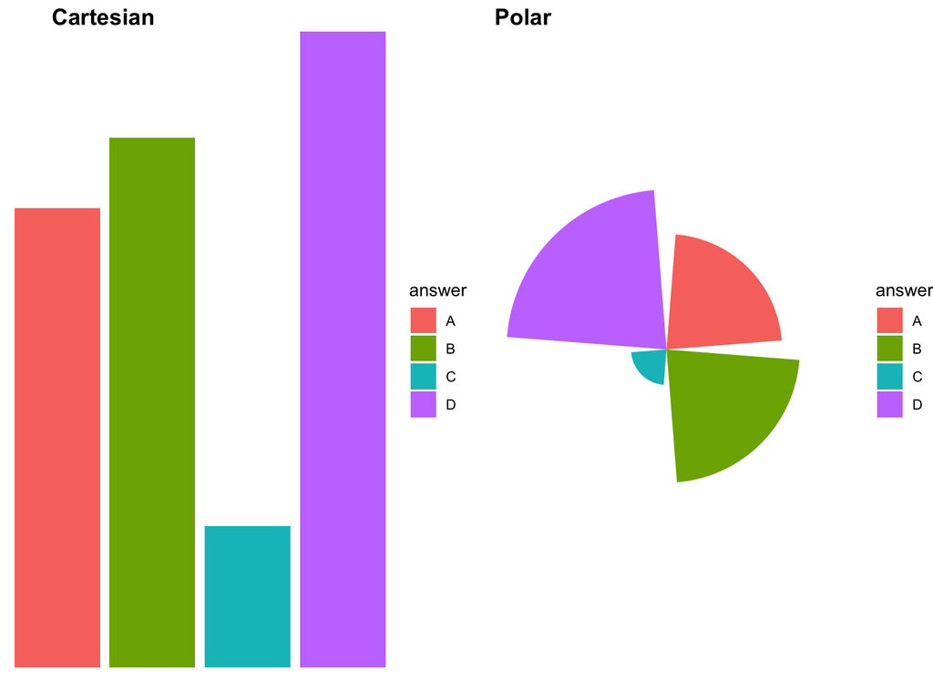

```r
# First plot
p1 <- ggplot(exam, aes(x = answer, fill = answer)) +
  geom_bar()

# Second plot
p2 <- ggplot(exam, aes(x = answer, fill = answer)) +
  geom_bar() +
  coord_polar()

plot_grid(p1, p2, nrow = 1, labels = c("Cartesian", "Polar"))
```

#### Swirling bull’s-eye?

```r
# your R code goes here
```

#### Normal pie chart

```r
# your R code goes here
```

#### Concentric circles

```r
# your R code goes here
```